# Effects of Storms on Health and Wealth in USA

Asad Husain

29/03/2020

## Table of Contents

- Data Processing
  - Retrieval and Loading
  - Cleaning and Preparation
- Results
  - Event Types Most Harmful to Population Health
  - Event Types with Greatest Economic Consequences
- Appendices
  - Appendix A - Review of Top Individual Events During Data Preparation
  - Appendix B - EVTYPE to EventType Translation Results
  - Appendix C - Uncategorized EVTYPE Values

## Synopsis

Storms and other severe weather events can cause both public health and economic problems for communities and municipalities. Many severe events can result in fatalities, injuries, and property damage, and preventing such outcomes to the extent possible is a key concern. This project involves exploring the U.S. National Oceanic and Atmospheric Administration’s (NOAA) storm database. This database tracks characteristics of major storms and weather events in the United States, including when and where they occur, as well as estimates of any fatalities, injuries, and property damage.The data for this assignment came in the form of a comma-separated-value file compressed via the bzip2 algorithm to reduce its size; there is also some documentation of the database available.The events in the database start in the year 1950 and end in November 2011. In the earlier years of the database there are generally fewer events recorded, most likely due to a lack of good records. More recent years should be considered more complete.

## Data Processing

### Retrieval and Loading

The compressed data is conditionally downloaded from the source URL if not found locally and then loaded directly via `read.csv`. It is then stored in a variable called `storm_data` and also ensured that the whole process is completed properly by checking the dimensions of the data-set.

```r
#Suppressing the many warnings
options(warn=-1)

#Loading relevant libraries
library(dplyr)
library(ggplot2)
library(data.table)
library(DT)
library(knitr)

#Set the working directory
#Downloading the file (when not present)
url <- "https://d396qusza40orc.cloudfront.net/repdata%2Fdata%2FStormData.csv.bz2"
filename <- "Storm_Data.csv.bz2"
if (!file.exists(filename)){
    download.file(url,filename)
}

storm_data <- read.csv(bzfile("Storm_Data.csv.bz2"))

# Ensure we got the data downloaded, decompressed and loaded correctly by checking the dataset dimemsions
stopifnot(dim(storm_data) == c(902297,37))
```

### Cleaning the Data

After the data-set is loaded, it is cleaned as follows:

1. Given the poor quality of the property and crop damage exponent variables (`PROPDMGEXP` and `CROPDMGEXP`), two variables are added to hold converted multiplier values named `PropDamageMult` and `CropDamageMult`. The function `convertExponentToMultiplier` is used to convert the original exponent variables into the corresponding multipliers.

```r
#Suppressing the many warnings
options(warn=-1)

convertExponentToMultiplier <- function(p){
  if(p %in% c("0","+","?","-",""))       #'0' '+' '?' '-' ' ' >> 0
    return(as.numeric(0))
  else if (p %in% c("1"))                #'1' >> 10
    return(as.numeric(10))
  else if (p %in% c("H","h","2"))        #'H' 'h' '2' >> 100 (1 Hundred)
    return(as.numeric(100))
  else if (p %in% c("K","k","3"))        #'K' 'k' '3' >> 1,000 (1 Thousand)
    return(as.numeric(1000))
  else if (p %in% c("4"))                #'4' >> 10,000
    return(as.numeric(10000))
  else if (p %in% c("5"))                #'5' >> 100,000
    return(as.numeric(100000))
  else if (p %in% c("M","m","6"))        #'M' 'm' '6' >> 1,000,000 (1 Million)
    return(as.numeric(1000000))
  else if (p %in% c("7"))                #'7' >> 10,000,000
    return(as.numeric(10000000))
  else if (p %in% c("8"))                #'8' >> 100,000,000
    return(as.numeric(100000000))
  else if (p %in% c("B","b","9"))        #'B' 'b' '9' >> 1,000,000,000 (1 Billion)
    return(as.numeric(1000000000))
  else
    print(p)
    stop("Unexpected Value")
}

storm_data$PropDamageMult <- convertExponentToMultiplier(storm_data$PROPDMGEXP)
storm_data$CropDamageMult <- convertExponentToMultiplier(storm_data$CROPDMGEXP)
```

2. With the multiplier variables created, `CropDamage` and `PropDamage` variables are added by multiplying them against the corresponding damage variables `PROPDMG` and `CROPDMG`. In addition, a `TotalDamage` variable is also added, using the sum of both the crop and property damage.

```r
storm_data$PropDamage  <- storm_data$PROPDMG * storm_data$PropDamageMult
storm_data$CropDamage  <- storm_data$CROPDMG * storm_data$CropDamageMult
storm_data$TotalDamage <- storm_data$PropDamage + storm_data$CropDamage
```

3. For determining the overall health impact of events, a `PopulationHealthImpact` variable is added using the sum of `FATALITIES` and `INJURIES` variables.

```r
storm_data$PopulationHealthImpact <- storm_data$FATALITIES + storm_data$INJURIES
```

4. To make the data-set easier to work with, irrelevant observations are removed. According to the documentation, it was not until 1996 that all event types were being recorded. For that reason, the years from the data-set earlier than that are removed in order to get a fair assessment of all events. Also, since we are answering questions around economic and population health impact, all rows having neither of these are removed as well.

```r
storm_data$BeginDate <- as.Date(storm_data$BGN_DATE, format = "%m/%d/%Y %H:%M:%S")
sd <- storm_data[storm_data$BeginDate >= '1996-01-01',]
sd <- sd[sd$TotalDamage > 0 | sd$PopulationHealthImpact  > 0,]
```

```r
#Suppressing the many warnings
options(warn=-1)

sd$PROPDMGEXP[sd$REFNUM=='605943'] <- 'M'
sd$PropDamageMult <- convertExponentToMultiplier(sd$PROPDMGEXP)
sd$PropDamage  <- sd$PROPDMG * sd$PropDamageMult
sd$TotalDamage <- sd$PropDamage + sd$CropDamage
```

6. Given the poor consistency of the values found in the `EVTYPE` variable, it was decided to use the list of Event names from Section 2.1.1 of the [Storm Data Documentation](https://d396qusza40orc.cloudfront.net/repdata%2Fpeer2_doc%2Fpd01016005curr.pdf). Using various techniques, a new tidy variable named `EventType` was created containing one of these 48 event types or the value `UNCATEGORIZED` indicating the event was not included. All observations start off as `UNCATEGORIZED` and then updated with different approaches with one of the 48 values.

```r
eventTypes <- c('Astronomical Low Tide', 'Avalanche', 'Blizzard', 'Coastal Flood', 'Cold/Wind Chill',
                'Debris Flow', 'Dense Fog', 'Dense Smoke', 'Drought', 'Dust Devil', 'Dust Storm',
                'Excessive Heat', 'Extreme Cold/Wind Chill', 'Flash Flood', 'Flood', 'Frost/Freeze',
                'Funnel Cloud', 'Freezing Fog', 'Hail', 'Heat', 'Heavy Rain', 'Heavy Snow', 'High Surf',
                'High Wind', 'Hurricane (Typhoon)', 'Ice Storm', 'Lake-Effect Snow', 'Lake-shore Flood',
                'Lightning', 'Marine Hail', 'Marine High Wind', 'Marine Strong Wind',
                'Marine Thunderstorm Wind', 'Rip Current', 'Seiche', 'Sleet', 'Storm Surge/Tide',
                'Strong Wind', 'Thunderstorm Wind', 'Tornado', 'Tropical Depression', 'Tropical Storm',
                'Tsunami', 'Volcanic Ash', 'Waterspout', 'Wildfire', 'Winter Storm', 'Winter Weather')
sd$EventType <- 'UNCATEGORIZED'  # start all EventTypes off as "Uncategorized"
```

The `EVTYPE` variable was first updated for consistency by removing all white-space and making all upper case.

```r
sd$EVTYPE <- toupper(trimws(sd$EVTYPE))
```

The initial pass of setting `EventType` values from `EVTYPE` data was a simple text matching approach based on:

- Ignoring all white-space and capitalization
- Ignoring all non-alpha characters
- Allowing for plural variations (WIND/WIND**S**)
- Allowing for verb variations (FLOOD/FLOOD**ING**)

```r
regex <- "[^[:alpha:]]" # match all non-alpha
for(eventType in eventTypes) {
  strippedEventType <- toupper(gsub(regex, '', eventType))
  sd$EventType[gsub(regex, '', sd$EVTYPE) == strippedEventType] <- eventType
  sd$EventType[gsub(regex, '', sd$EVTYPE) == paste(strippedEventType, 'S',   sep='')] <- eventType
  sd$EventType[gsub(regex, '', sd$EVTYPE) == paste(strippedEventType, 'ING', sep='')] <- eventType
}
```

The next step of populating `EventType` was a manual mapping using `EVTYPE` values. Some were obvious abbreviations (`TSTM WIND` -> `Thunderstorm Wind`). Other values required reviewing the [Storm Data Documentation](https://d396qusza40orc.cloudfront.net/repdata%2Fpeer2_doc%2Fpd01016005curr.pdf) for better understanding. For example `LANDSPOUT` was mapped to `Tornado` and not `Dust Devil` because on page 75 it states:

> Land-spouts and cold-air funnels, ultimately meeting the objective tornado criteria listed in Section 7.40.6, will be classified as Tornado events.

This manual process was done iteratively while reviewing the damage and health impact totals for the remaining uncategorized `EVTYPE` values until it was determined that further work would not have any meaningful impact to the overall result of this report. See appendix B for the final `EventType` to `EVTYPE` value mappings and appendix C for more information on the `EVTYPE` values that were left uncategorized.

```r
coastalFloodAliases <- c('ASTRONOMICAL HIGH TIDE', 'TIDAL FLOODING', 'COASTAL FLOODING/EROSION',
                         'COASTAL  FLOODING/EROSION', 'EROSION/CSTL FLOOD')
sd$EventType[sd$EVTYPE %in% coastalFloodAliases] <- 'Coastal Flood'

winterWeatherAliases <- c('LIGHT FREEZING RAIN', 'ICY ROADS', 'GLAZE', 'FREEZING RAIN',
                          'FREEZING DRIZZLE', 'LIGHT SNOW', 'LIGHT SNOWFALL', 'WINTER WEATHER/MIX',
                          'MIXED PRECIPITATION', 'MIXED PRECIP', 'WINTRY MIX', 'RAIN/SNOW',
                          'WINTER WEATHER MIX')
sd$EventType[sd$EVTYPE %in% winterWeatherAliases] <- 'Winter Weather'

heavySnowAliases <- c('EXCESSIVE SNOW', 'SNOW', 'HEAVY SNOW SHOWER', 'SNOW SQUALL', 'SNOW SQUALLS')
sd$EventType[sd$EVTYPE %in% heavySnowAliases] <- 'Heavy Snow'

highWindAliases <- c('WIND', 'WINDS', 'GUSTY WINDS', 'GUSTY WIND', 'HIGH WIND (G40)',
                     'NON TSTM WIND',  'NON-TSTM WIND', 'WIND DAMAGE', 'NON TSTM WIND',
                     'NON-SEVERE WIND DAMAGE', 'GRADIENT WIND')
sd$EventType[sd$EVTYPE %in% highWindAliases] <- 'High Wind'

freezeAliases <- c('FREEZE', 'DAMAGING FREEZE', 'EARLY FROST', 'FROST', 'AGRICULTURAL FREEZE',
                   'HARD FREEZE', 'UNSEASONABLY COLD', 'UNSEASONABLE COLD')
sd$EventType[sd$EVTYPE %in% freezeAliases] <- 'Frost/Freeze'

extremeColdAliases <- c('EXTREME WINDCHILL', 'EXTREME COLD')
sd$EventType[sd$EVTYPE %in% extremeColdAliases] <- 'Extreme Cold/Wind Chill'

floodAliases <- c('RIVER FLOODING', 'RIVER FLOOD', 'URBAN/SML STREAM FLD', 'URBAN FLOOD')
sd$EventType[sd$EVTYPE %in% floodAliases] <- 'Flood'

flashFloodAliases <- c('FLASH FLOOD/FLOOD', 'FLOOD/FLASH/FLOOD')
sd$EventType[sd$EVTYPE %in% flashFloodAliases] <- 'Flash Flood'

thunderstormAliases <- c('TSTM WIND', 'TSTM WINDS', 'THUNDERSTORM', 'THUNDERSTORMS',
                         'THUNDERSTORM WINDSS', 'THUNDERSTORMS WINDS', 'DRY MICROBURST',
                         'TSTM WIND (G40)', 'THUNDERSTORM WIND/ TREES', 'MICROBURST',
                         'WET MICROBURST', 'THUNDERTORM WINDS', 'THUNDERSTORMS WIND',
                         'SEVERE THUNDERSTORM WINDS', 'TSTM WIND 55', 'THUNDERSTORM WIND 60 MPH',
                         'TSTM WIND (G45)', 'SEVERE THUNDERSTORM', 'THUDERSTORM WINDS',
                         'THUNDEERSTORM WINDS', 'THUNDERESTORM WINDS', 'TSTM WIND 40',
                         'TSTM WIND G45', 'TSTM WIND  (G45)', 'TSTM WIND (41)', 'TSTM WIND 45',
                         'TSTM WIND (G35)', 'TSTM WIND AND LIGHTNING', 'TSTM WIND/HAIL',
                         'THUNDERSTORM WIND (G40)')
sd$EventType[sd$EVTYPE %in% thunderstormAliases] <- 'Thunderstorm Wind'

hailAliases <- c('HAIL DAMAGE', 'SMALL HAIL', 'HAILSTORM')
sd$EventType[sd$EVTYPE %in% hailAliases] <- 'Hail'

hurricaneAliases <- c('HURRICANE', 'TYPHOON', 'HURRICANE OPAL', 'HURRICANE ERIN',
                      'HURRICANE EDOUARD', 'HURRICANE EMILY', 'HURRICANE FELIX',
                      'HURRICANE GORDON', 'HURRICANE OPAL/HIGH WINDS')
sd$EventType[sd$EVTYPE %in% hurricaneAliases] <- 'Hurricane (Typhoon)'

highSurfAliases <- c('HEAVY SURF/HIGH SURF', 'HEAVY SURF', 'HIGH SURF ADVISORY')
sd$EventType[sd$EVTYPE %in% highSurfAliases] <- 'High Surf'

wildfireAliases = c('WILD/FOREST FIRE', 'BRUSH FIRE')
sd$EventType[sd$EVTYPE %in% wildfireAliases] <- 'Wildfire'

heatAliases = c('UNSEASONABLY WARM', 'WARM WEATHER')
sd$EventType[sd$EVTYPE %in% heatAliases] <- 'Heat'

excessiveHeatAliases = c('HEAT WAVE', 'RECORD HEAT')
sd$EventType[sd$EVTYPE %in% excessiveHeatAliases] <- 'Excessive Heat'

heavyRainAliases = c('TORRENTIAL RAINFALL', 'RAIN', 'UNSEASONAL RAIN')
sd$EventType[sd$EVTYPE %in% heavyRainAliases]  <- 'Heavy Rain'

# one-offs
sd$EventType[sd$EVTYPE == 'LANDSPOUT']         <- 'Tornado'
sd$EventType[sd$EVTYPE == 'FOG']               <- 'Dense Fog'
sd$EventType[sd$EVTYPE == 'MARINE TSTM WIND']  <- 'Marine Thunderstorm Wind'
sd$EventType[sd$EVTYPE == 'LANDSLIDE']         <- 'Debris Flow'
sd$EventType[sd$EVTYPE == 'STORM SURGE']       <- 'Storm Surge/Tide'
sd$EventType[sd$EVTYPE == 'COLD']              <- 'Cold/Wind Chill'
```

## Results

### Event Types Most Harmful to Population Health

```r
top_health <- head(
  arrange(
    aggregate(
      cbind(FATALITIES, INJURIES, PopulationHealthImpact) ~ EventType, sd, FUN = sum),
    desc(PopulationHealthImpact)),
  n=10)

kable(
  top_health,
  caption = 'Top 5 Event Types Most Harmful to Population Health')
```

| EventType | FATALITIES | INJURIES | PopulationHealthImpact |
| --- | --- | --- | --- |
| Tornado | 1511 | 20667 | 22178 |
| Excessive Heat | 1799 | 6461 | 8260 |
| Flood | 444 | 6838 | 7282 |
| Thunderstorm Wind | 382 | 5154 | 5536 |
| Lightning | 651 | 4141 | 4792 |
| Flash Flood | 887 | 1674 | 2561 |
| Wildfire | 87 | 1458 | 1545 |
| Winter Storm | 191 | 1292 | 1483 |
| Heat | 237 | 1241 | 1478 |
| Hurricane (Typhoon) | 125 | 1328 | 1453 |

Tornado events top the list here, with over two and half times the health impact of second place, which is Excessive Heat. Excessive Heat is worth noting however due to the fact that even though it is far behind tornados in total health impact, but has the most fatalities overall.

Next we will look a bit deeper at the data, plotting the yearly total health impact for these top 10.

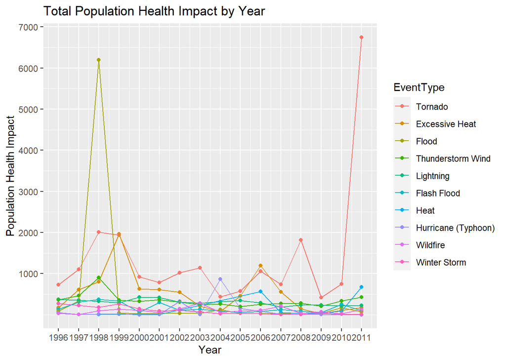

```r
health_by_type_and_year <- aggregate(
  cbind(FATALITIES, INJURIES, PopulationHealthImpact) ~ EventType + year(BeginDate),
  sd,
  FUN=sum)

names(health_by_type_and_year) <- c('EventType', 'Year', 'Fatalities', 'Injuries', 'PopulationHealthImpact')

health_by_type_and_year <- health_by_type_and_year[health_by_type_and_year$EventType %in% top_health$EventType,]

health_by_type_and_year$EventType <- with(health_by_type_and_year, reorder(EventType, -PopulationHealthImpact))

ggplot(health_by_type_and_year, aes(x=Year, y=PopulationHealthImpact, colour = EventType)) +
  geom_point() +
  geom_line() +
  scale_x_continuous(breaks = unique(health_by_type_and_year$Year)) +
  scale_y_continuous('Population Health Impact', breaks = seq(1000, 7000, by=1000)) +
  ggtitle("Total Population Health Impact by Year")
```

Here we see two years with significant outliers. In 1998 there was an extremely high health related impact due to flood events. Looking at the [NOAA Summary of Natural Hazard Statistics for 1998](http://www.nws.noaa.gov/om/hazstats/sum98.pdf) shows that a flood in south-central Texas caused over 6,000 injuries accounting for most of that year’s total. The Tornado spike in 2011 can be accounted for due to record breaking spring and summer tornado season according to the [NOAA Tornado Annual 2011 Report](https://www.ncdc.noaa.gov/sotc/tornadoes/201113).

Looking at the plot, Tornadoes have a solid yearly trend despite the record breaking year, so their number one position is not due to that year alone. Flood events however have an overall low yearly trend in comparison to the other top 5 except for 1998. Without this year, flood events would have been in last place instead of third amongst the current top 5. Additional analysis would be needed, but there is good chance it would not have even made the top 5 at all without the 1998 Texas floods.

### Event Types with Greatest Economic Consequences

```r
top_damage <- head(
  arrange(
    aggregate(
      cbind(CropDamage, PropDamage, TotalDamage) ~ EventType, sd, FUN=sum),
    desc(TotalDamage)),
  n=10)

kable(
  top_damage,
  format.args = list(big.mark = ","),
  caption = 'Top 5 Event Types with Greatest Economic Consequences')
```

| EventType | CropDamage | PropDamage | TotalDamage |
| --- | --- | --- | --- |
| Thunderstorm Wind | 0 | 2,203,670,870 | 2,203,670,870 |
| Flash Flood | 0 | 1,247,627,540 | 1,247,627,540 |
| Tornado | 0 | 1,187,885,230 | 1,187,885,230 |
| Flood | 0 | 861,052,140 | 861,052,140 |
| Hail | 0 | 575,387,280 | 575,387,280 |
| Lightning | 0 | 488,561,850 | 488,561,850 |
| High Wind | 0 | 318,594,600 | 318,594,600 |
| Winter Storm | 0 | 126,910,490 | 126,910,490 |
| Wildfire | 0 | 122,315,280 | 122,315,280 |
| Heavy Snow | 0 | 92,223,880 | 92,223,880 |

Again, we will look at the yearly trend for these top 10.

[figure not shown]

```r
damage_by_type_and_year <-  aggregate(
  cbind(CropDamage,PropDamage,TotalDamage)~EventType+year(BeginDate),
  sd,
  FUN=sum)

names(damage_by_type_and_year) <- c('EventType', 'Year', 'CropDamage', 'PropDamage', 'TotalDamage')

sd_dmg_yearly <- damage_by_type_and_year[damage_by_type_and_year$EventType %in% top_damage$EventType,]

sd_dmg_yearly$EventType <- with(sd_dmg_yearly, reorder(EventType, -TotalDamage))

ggplot(sd_dmg_yearly, aes(Year, TotalDamage / 10^9, colour = EventType)) +
  geom_point() +
  geom_line() +
  scale_x_continuous(breaks = unique(damage_by_type_and_year$Year)) +
  scale_y_continuous('Total Economic Impact (Billions)', labels = scales::dollar, breaks = seq(5,50, by=5)) +
  ggtitle('Total Economic Impact by Year')
```

## Appendices

### Appendix A - Review of Top Individual Events During Data Preparation

During data preparation the list of top 5 individual events by total damage and population health impact were reviewed and checked for consistency against the [NOAA Storm Events Database](https://www.ncdc.noaa.gov/stormevents/choosedates.jsp?statefips=-999%2CALL).

#### Top Individual Events By Total Damage

```r
top_events_by_total_damage <- subset(storm_data, BeginDate  >= '1996-01-01')
top_events_by_total_damage <-top_events_by_total_damage [
  order(-top_events_by_total_damage$TotalDamage, top_events_by_total_damage$EVTYPE),
  c('REFNUM', 'STATE', 'BeginDate', 'EVTYPE', 'CROPDMG', 'CROPDMGEXP', 'PROPDMG', 'PROPDMGEXP', 'TotalDamage')]

kable(
  head(
    top_events_by_total_damage,
    n =5),
  row.names = FALSE,
  caption = 'Top Five Individual Events by Total Economic Damage (prior to data correction)')
```

Top Five Individual Events by Total Economic Damage (prior to data correction)

| REFNUM | STATE | BeginDate | EVTYPE | CROPDMG | CROPDMGEXP | PROPDMG | PROPDMGEXP | TotalDamage |
| --- | --- | --- | --- | --- | --- | --- | --- | --- |
| 808182 | IL | 2010-05-13 | FLASH FLOOD | 0 | K | 5000 | K | 5000000 |
| 808183 | IL | 2010-05-13 | FLASH FLOOD | 0 | K | 5000 | K | 5000000 |
| 778558 | NC | 2009-07-26 | THUNDERSTORM WIND | 0 | K | 5000 | K | 5000000 |
| 900646 | AM | 2011-10-29 | WATERSPOUT | 0 | K | 5000 | K | 5000000 |
| 791393 | PR | 2009-12-25 | LANDSLIDE | 0 | K | 4800 | K | 4800000 |

#### Top Individual Events By Population Health Impact

The same review of the top 5 individual events for total population health impact was also done and all were found to be in line with the current NOAA data.

```r
top_events_by_health_impact <- subset(storm_data, BeginDate  >= '1996-01-01')
top_events_by_health_impact <-top_events_by_health_impact [
  order(-top_events_by_health_impact$PopulationHealthImpact, top_events_by_health_impact$EVTYPE),
 c('REFNUM', 'STATE', 'BeginDate', 'EVTYPE', 'INJURIES', 'FATALITIES', 'PopulationHealthImpact')]

kable(
  head(
    top_events_by_health_impact,
    n =5),
  row.names = FALSE,
  caption = 'Top Five Individual Events by Population Health Impact')
```

Top Five Individual Events by Population Health Impact

| REFNUM | STATE | BeginDate | EVTYPE | INJURIES | FATALITIES | PopulationHealthImpact |
| --- | --- | --- | --- | --- | --- | --- |
| 862563 | MO | 2011-05-22 | TORNADO | 1150 | 158 | 1308 |
| 860355 | AL | 2011-04-27 | TORNADO | 800 | 44 | 844 |
| 344098 | TX | 1998-10-17 | FLOOD | 800 | 2 | 802 |
| 529299 | FL | 2004-08-13 | HURRICANE/TYPHOON | 780 | 7 | 787 |
| 344117 | TX | 1998-10-17 | FLOOD | 750 | 0 | 750 |

- REFNUM 862563: NOAA link 5/22/2011, MO, Jasper, Tornado
- REFNUM 860355: NOAA link 4/27/2011, AL, Tuscaloosa, Tornado
- REFNUM 344098: NOAA link 10/17/1998, TX, Comal, Flood
- REFNUM 529299: NOAA link 8/13/2004, FL, Hurricane
- REFNUM 344117: NOAA link 10/17/1998, TX, Flood

### Appendix B - EVTYPE to EventType Translation Results

Below shows each `EventType` that had multiple `EVTYPE` values grouped into it as a result of the translation process along with each of those `EVTYPE` values. `EventType` values with just a single `EVTYPE` were omitted here because they were simply the upper case equivalent.

```r
eventType_by_EVTYPE <- unique(subset(sd[sd$EventType != 'UNCATEGORIZED',], select=c(EventType, EVTYPE)))
eventType_by_EVTYPE <- eventType_by_EVTYPE[order(eventType_by_EVTYPE$EventType, eventType_by_EVTYPE$EVTYPE),]
for (eventType in unique(eventType_by_EVTYPE$EventType)) {
  if(length(eventType_by_EVTYPE$EVTYPE[eventType_by_EVTYPE$EventType==eventType]) > 1) {
    k <- kable(
      eventType_by_EVTYPE$EVTYPE[eventType_by_EVTYPE$EventType==eventType],
      row.names = FALSE,
      col.names = eventType)
    print(k)
  }
}
```

| Coastal Flood |
| --- |
| ASTRONOMICAL HIGH TIDE |
| COASTAL FLOODING/EROSION |
| COASTAL FLOOD |
| COASTAL FLOODING |
| COASTAL FLOODING/EROSION |
| EROSION/CSTL FLOOD |
| TIDAL FLOODING |

| Cold/Wind Chill |
| --- |
| COLD |
| COLD/WIND CHILL |

| Dense Fog |
| --- |
| DENSE FOG |
| FOG |

| Excessive Heat |
| --- |
| EXCESSIVE HEAT |
| HEAT WAVE |
| RECORD HEAT |

| Extreme Cold/Wind Chill |
| --- |
| EXTREME COLD |
| EXTREME COLD/WIND CHILL |
| EXTREME WINDCHILL |

| Flash Flood |
| --- |
| FLASH FLOOD |
| FLASH FLOOD/FLOOD |
| FLOOD/FLASH/FLOOD |

| Flood |
| --- |
| FLOOD |
| RIVER FLOOD |
| RIVER FLOODING |
| URBAN/SML STREAM FLD |

| Frost/Freeze |
| --- |
| DAMAGING FREEZE |
| FREEZE |
| FROST |
| FROST/FREEZE |

| Hail |
| --- |
| HAIL |
| SMALL HAIL |

| Heat |
| --- |
| HEAT |
| UNSEASONABLY WARM |
| WARM WEATHER |

| Heavy Rain |
| --- |
| HEAVY RAIN |
| RAIN |
| TORRENTIAL RAINFALL |

| Heavy Snow |
| --- |
| EXCESSIVE SNOW |
| HEAVY SNOW |
| HEAVY SNOW SHOWER |
| SNOW |
| SNOW SQUALL |
| SNOW SQUALLS |

| High Surf |
| --- |
| HEAVY SURF |
| HEAVY SURF/HIGH SURF |
| HIGH SURF |
| HIGH SURF ADVISORY |

| High Wind |
| --- |
| GRADIENT WIND |
| GUSTY WIND |
| GUSTY WINDS |
| HIGH WIND |
| HIGH WIND (G40) |
| HIGH WINDS |
| NON-SEVERE WIND DAMAGE |
| NON-TSTM WIND |
| NON TSTM WIND |
| WIND |
| WIND DAMAGE |
| WINDS |

| Hurricane (Typhoon) |
| --- |
| HURRICANE |
| HURRICANE EDOUARD |
| HURRICANE/TYPHOON |
| TYPHOON |

| Lake-Effect Snow |
| --- |
| LAKE-EFFECT SNOW |
| LAKE EFFECT SNOW |

| Marine Thunderstorm Wind |
| --- |
| MARINE THUNDERSTORM WIND |
| MARINE TSTM WIND |

| Rip Current |
| --- |
| RIP CURRENT |
| RIP CURRENTS |

| Storm Surge/Tide |
| --- |
| STORM SURGE |
| STORM SURGE/TIDE |

| Strong Wind |
| --- |
| STRONG WIND |
| STRONG WINDS |

| Thunderstorm Wind |
| --- |
| DRY MICROBURST |
| MICROBURST |
| THUNDERSTORM |
| THUNDERSTORM WIND |
| THUNDERSTORM WIND (G40) |
| TSTM WIND |
| TSTM WIND (G45) |
| TSTM WIND (41) |
| TSTM WIND (G35) |
| TSTM WIND (G40) |
| TSTM WIND (G45) |
| TSTM WIND 40 |
| TSTM WIND 45 |
| TSTM WIND AND LIGHTNING |
| TSTM WIND G45 |
| TSTM WIND/HAIL |
| WET MICROBURST |

| Tornado |
| --- |
| LANDSPOUT |
| TORNADO |

| Wildfire |
| --- |
| BRUSH FIRE |
| WILD/FOREST FIRE |
| WILDFIRE |

| Winter Weather |
| --- |
| FREEZING DRIZZLE |
| FREEZING RAIN |
| GLAZE |
| ICY ROADS |
| LIGHT FREEZING RAIN |
| LIGHT SNOW |
| LIGHT SNOWFALL |
| MIXED PRECIP |
| MIXED PRECIPITATION |
| RAIN/SNOW |
| WINTER WEATHER |
| WINTER WEATHER MIX |
| WINTER WEATHER/MIX |
| WINTRY MIX |

### Appendix C - Uncategorized EVTYPE Values

Here is the list of `EVTYPE` values not translated and left with an `EventType` value of `UNCATEGORIZED`. Also included are the sum of the calculated `TotalDamage` and `PopulationHealthImpact` totals. These were omitted due to a proper `EventType` value not being obvious. These include values like `OTHER` with no obvious match as well as `GUSTY WIND/HVY RAIN` which matches potentially to more than one `EventType`. Given the relatively low amount of damage and health impact values for these remaining types, omitting them would have no impact to the overall result of the analysis.

```r
uc <- sd[sd$EventType=='UNCATEGORIZED',]
uncat <- arrange(aggregate(cbind(TotalDamage,PopulationHealthImpact) ~ EVTYPE, uc, FUN=sum),EVTYPE)

datatable(uncat, caption = 'UNCATEGORIZED events contribution',options = list(dom = 'tp',
    initComplete = JS(
    "function(settings, json) {",
    "$(this.api().table().header()).css({'background-color': '#000', 'color': '#fff'});",
    "}")))
```

|  | EVTYPE | TotalDamage | PopulationHealthImpact |
| --- | --- | --- | --- |
| 1 | BEACH EROSION | 100000 | 0 |
| 2 | BLACK ICE | 0 | 25 |
| 3 | BLOWING DUST | 20000 | 0 |
| 4 | BLOWING SNOW | 15000 | 2 |
| 5 | COASTAL EROSION | 766000 | 0 |
| 6 | COASTAL STORM | 50000 | 5 |
| 7 | COASTALSTORM | 0 | 1 |
| 8 | COLD AND SNOW | 0 | 14 |
| 9 | COLD TEMPERATURE | 0 | 2 |
| 10 | COLD WEATHER | 0 | 2 |

[output cut: 36 more lines]